# 1860s Sentiment towards animal cruelty

Oliver Hofman

2026-05-20

```r
knitr::opts_chunk$set(echo = TRUE)
library(tidyverse)
library(tidytext)
```

```r
library(ggwordcloud)
library(syuzhet)
```

# Loading the data into R

using Swagger UI, a link is created from the search “dyrplager* py:[1860-69]” in Mediestream

```r
link <- "https://labs.statsbiblioteket.dk/labsapi/api/aviser/export/fields?query=dyrplager%2A%20py%3A%5B1860%20TO%201869%5D&fields=link&fields=recordID&fields=timestamp&fields=pwa&fields=cer&fields=fulltext_org&fields=pageUUID&fields=editionUUID&fields=titleUUID&fields=editionId&fields=familyId&fields=newspaper_page&fields=newspaper_edition&fields=lplace&fields=location_name&fields=location_coordinates&max=-1&structure=header&structure=content&format=CSV"

URLdecode(link)
```

```
## [1] "https://labs.statsbiblioteket.dk/labsapi/api/aviser/export/fields?query=dyrplager* py:[1860 TO 1869]&fields=link&fields=recordID&fields=timestamp&fields=pwa&fields=cer&fields=fulltext_org&fields=pageUUID&fields=editionUUID&fields=titleUUID&fields=editionId&fields=familyId&fields=newspaper_pa…
```

```r
Dyr_1860s <- read.csv(link)
```

# Analysing the datas origin

Here its seen that Copenhagen is in the clear lead, with quite the drop to the next most. it also shows that “flyveposten” is the paper with most mentions, with berlingske right behind it.

```r
Dyr_1860s %>%
  count(lplace, sort = TRUE)
```

```
##              lplace   n
## 1         København 261
## 2           Horsens  39
## 3  Nykøbing Falster  29
## 4             Rønne  25
## 5           Aalborg  19
## 6        Middelfart  19
## 7          Ringsted  19
## 8            Aarhus  17
## 9          Hillerød  17
## 10        Silkeborg  17
## 11           Odense  16
## 12          Thisted  16
## 13            Århus  14
## 14       Nykøbing S  13
```

[output cut: 19 more lines]

```r
Dyr_1860s %>%
  count(familyId, sort = TRUE)
```

```
##                        familyId  n
## 1                   flyveposten 52
## 2             berlingsketidende 47
## 3              faedrelandet1834 46
## 4               dagstelegraphen 42
## 5       dagbladetkoebenhavn1851 31
## 6               horsensavis1828 31
## 7               folketsavis1860 29
## 8  lollandfalstersstiftstidende 29
## 9          aalborgstiftstidende 19
## 10           middelfartavis1857 19
## 11     sjaellandspostenringsted 19
## 12          aarhusstiftstidende 17
## 13     frederiksborgamtstidende 17
## 14         midtjyllandsavis1857 17
```

[output cut: 32 more lines]

#Textmining Here the articles are divided up into singular words and then edited by using a list of stopwords pertaining to especially 1800s danish.

```r
Dyr_1860s_tidy <- Dyr_1860s %>%
  unnest_tokens(word, fulltext_org)

stopwords_1800s <- read_csv("https://gist.githubusercontent.com/maxodsbjerg/1537cf14c3d46b3d30caa5d99f8758e9/raw/9f044a38505334f035be111c9a3f654a24418f6d/stopord_18_clean.csv")
Dyr_1860s_wStopwords<- Dyr_1860s_tidy %>%
  anti_join(stopwords_1800s) %>%
  count(word, sort = TRUE)
```

#Removing numerals and creating a top 100 Here numbers are filtered out, as to only get actual words that can be analysed. Then its put into a top 100 of most mentions

```r
Dyr_1860s_nonum <- Dyr_1860s_wStopwords %>%
filter(!str_detect(word, "[0-9]"))

 Dyr_1860s_top100 <- head(Dyr_1860s_nonum, 100)

 Dyr_1860s_top100
```

```
##           word   n
## 1   dyrplageri 740
## 2       maatte 327
## 3         selv 321
## 4        heste 319
## 5        anden 315
## 6          sag 314
## 7        siden 313
## 8       derfor 312
## 9     tiltalte 305
## 10         ban 291
## 11      mellem 290
## 12         mig 286
## 13        stal 284
## 14         kom 280
```

[output cut: 86 more lines]

#Wordcloud by creating a wordcloud with the top 100, its made easier to visualize whats mentioned the most.

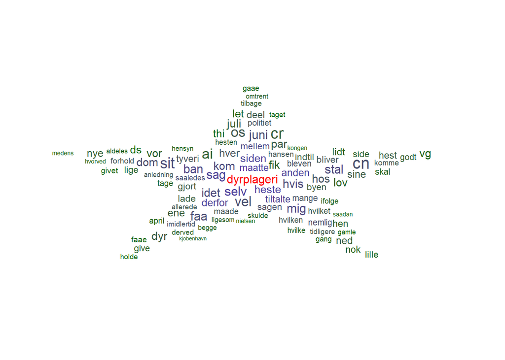

```r
ggplot(data = Dyr_1860s_top100, aes(label = word, size = n)) +
  geom_text_wordcloud_area(aes(color = n), shape = "star") +
  scale_size_area(max_size = 12) +
  scale_color_gradientn(colors = c("darkgreen","blue","red")) +
  theme_minimal()
```

#Sentiment analysis here the text a once again edited with the stopwords, and then joined together as to get a overall sentiment score from the articles.

```r
fulltext_tidy_recordID <- Dyr_1860s_tidy %>%
  anti_join(stopwords_1800s, by = c("word" = "word")) %>%
  group_by(recordID) %>%
  summarise(fulltext_clean = paste(word, collapse = " "), .groups = "drop")

sentiment_text_recordID <- fulltext_tidy_recordID %>%
  mutate(
    fulltext_sentiment = map_dbl(
      fulltext_clean,
      function(x) get_sentiment(x, method = "afinn")
    )
  )
sentiment_by_record_1860s <- sentiment_text_recordID %>%
  group_by(recordID) %>%
  summarise(
    mean_sentiment = mean(fulltext_sentiment, na.rm = TRUE),
    n = n()
  )
```

#Visualizing the Sentiment here the articles sentiment score is plotted into a histogram to better visualize the spread of sentiment across all the articles

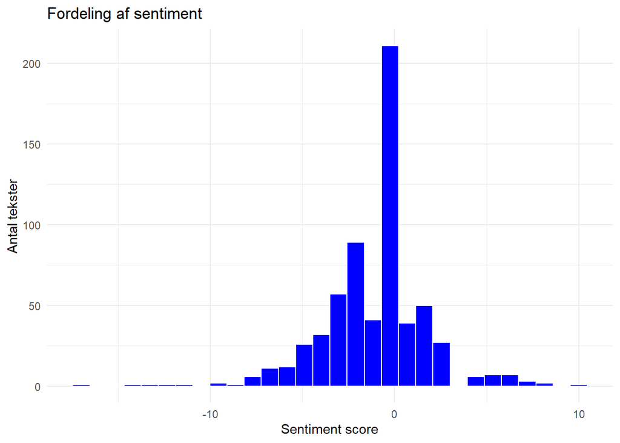

```r
library(ggplot2)

ggplot(sentiment_by_record_1860s,
       aes(x = mean_sentiment)) +
  geom_histogram(bins = 30,
                 fill = "Blue",
                 color = "white") +
  theme_minimal() +
  labs(
    title = "Fordeling af sentiment",
    x = "Sentiment score",
    y = "Antal tekster"
  )
```

#Average Sentiment Score here a average of the sentiment is calculated

```r
mean(sentiment_by_record_1860s$mean_sentiment,
     na.rm = TRUE)
```

```
## [1] -0.9023622
```

#Categorizing the sentiment by dividing all the articles into 3 Categories, “Positiv”, “Negativ” and “Neutral” and counting how many of the articles land into each categories

```r
sentiment_CAT_1860s <- sentiment_by_record_1860s %>%
  mutate(sentiment_category = case_when(
    mean_sentiment > 0 ~ "Positiv",
    mean_sentiment < 0 ~ "Negativ",
    TRUE ~ "Neutral"
  ))

sentiment_CAT_1860s %>%
  count(sentiment_category)
```

```
## # A tibble: 3 × 2
##   sentiment_category     n
##   <chr>              <int>
## 1 Negativ              282
## 2 Neutral              211
## 3 Positiv              142
```